# Wrangle Report

### Introduction

I wrangled and analyesed the dataset of the tweet archive of Twitter user @dog_rates, also known as WeRateDogs. WeRateDogs is a Twitter account that rates people's dogs with a humorous comment about the dog. WeRateDogs archive contains basic tweet data (tweet ID, timestamp, text, etc.) for all 5000+ of their tweets as they stood on August 1, 2017.

### Goal

It was to wrangle WeRateDogs Twitter data to create interesting and trustworthy analyses and visualizations.

### Data

The WeRateDogs Twitter archive contains basic tweet data for all 5000+ of their tweets. One column the archive does contain though: each tweet's text, dog name, and dog "stage" (i.e. doggo, floofer, pupper, and puppo) to make this Twitter archive "enhanced." Of the 5000+ tweets, filtered for tweets with ratings only (there are 2356). Retweet count and favorite count are two of the notable column omissions. This data could be gathered from Twitter's API. Every image in the WeRateDogs Twitter archive is run through a neural network that can classify breeds of dogs. The results: a table full of image predictions (the top three only) alongside each tweet ID, image URL, and the image number that corresponded to the most confident prediction (numbered 1 to 4 since tweets can have up to four images).

### Conclusion & findings

```python
# import softwares
import pandas as pd
import matplotlib.pyplot as plt
%matplotlib inline
```

```python
df = pd.read_csv('twitter_archive_master.csv')
```

The mean of the rating renumerator is 12.2

The popular dog names are: Charlie, Lucy, Cooper, Oliver. There are at least 10 dogs with these names.

The most common breeds found by the neural network are: golden retriever (137 counts), labrador retriever (94), pembroke (88), chihuahua (78), pug (54).

What is the dispersion of the accuracy of image recognition? See the histogram below.

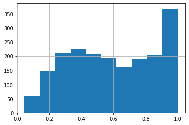

```python
df['p1_conf_x'].hist()
```